## Ist das Dein Buch?

Du willst also R lernen? Cool! Dafür kann es manche Gründe geben, aber sehr wahrscheinlich willst Du R in Zukunft benutzen, um Daten zu analysieren und zu visualisieren. Wenn Du dieses Buch liest, hast Du Dich bereits grundlegend über R informiert.

Damit dieses Buch ein durchgängiges Anspruchsniveau erhält, muss ich mir Gedanken über seine Leser machen, über Dich, darüber, was ich an Wissen und Erfahrung voraussetzen kann. Es macht natürlich einen grossen Unterschied, ob Du bereits mit anderen Sprachen gearbeitet hast oder mit R ganz neu in die Welt Programmierung einsteigst. Beide Szenarios schätze ich als häufig ein. Ist das also Dein Buch?

Das Buch ist primär dazu gedacht, R zu lernen, sekundär als möglicher Einstieg in die Programmierung. Wenn Du bereits Erfahrung mit anderen Sprachen gesammelt hast, macht das die Dinge einfacher, weil Du die Denkmuster und die Terminologie bereits kennst.

Ich versuche die Beispiele einfach genug zu halten, dass Du auch ohne vorherige Programmiererfahrung dem Buch folgen kannst. Das setzt aber eine sehr aktive Herangehensweise von Deiner Seite voraus, denn das Programmieren lernst Du nur indem Du es tust.

Erstens solltest Du Begriffe, die Dir fremd sind nachschlagen, z.B. mittels Wikipedia. Zweitens brauchst Du eine spielerische, aktive Herangehensweisea. Du musst viel ausprobieren, auch wenn Dich das Buch nicht direkt dazu auffordert, also aus eigenem Antrieb, bis Du fühlst, die Idee verstanden zu haben. Drittens brauchst Du den Mut Kapitel, die du nicht sofort verstehst, zu überspringen und das vor zu ziehen, was Dir zugänglicher erscheint.

Wenn diese aktive Herangehensweise nicht Deinem Naturell entspricht, empfehle ich, die Grundlagen des Programmierens auf andere Weise zu lernen, insbesondere in einem Kursus unter Anleitung. Solche Kurse als Einstieg in die Programmierung findest Du häufiger für andere Sprachen, wie Python, Java oder JavaScript. Die Denkmuster und Arbeitstechniken sind übertragbar. Die modernen Programmiersprachen sind sich ähnlicher als Du denkst.

Als Nachschlagewerk ist dieses Buch nicht gedacht. R hat eine gut Online-Hilfe zum Nachschlagen der Funktionen. Rezepte für Problemstellungen findest Du sowieso am besten mit Hilfe einer Suchmaschine.

## Einführung

### Hallo Welt in R

```r
print("Hallo Welt!")
```

```
## [1] "Hallo Welt!"
```

Bist Du enttäuscht? Nichts Neues im Vergleich zu anderen Sprachen? R ist eben leicht zu lernen.

Charakteristisches für R zeigt dieses kleine Programm. Wir berechen die Oberflächen meherer Planeten anhand ihres Radius, ohne dass eine Schleife nötig wird.

```r
names <- c("Merkur", "Venus", "Erde", "Mars")
radii <- c(2440, 6052, 6371, 3389)
surfaces <- round(4 * pi * radii^2 / 1000) * 1000
paste(names, ":", radii, "km, ", surfaces, "km^2")
```

```
## [1] "Merkur : 2440 km,  74815000 km^2" "Venus : 6052 km,  460265000 km^2"
## [3] "Erde : 6371 km,  510064000 km^2"  "Mars : 3389 km,  144329000 km^2"
```

Davon machen wir noch - quick and dirty - einen explorativen Plot, um zu sehen, wie die Fläche im Quadrat ansteigt.

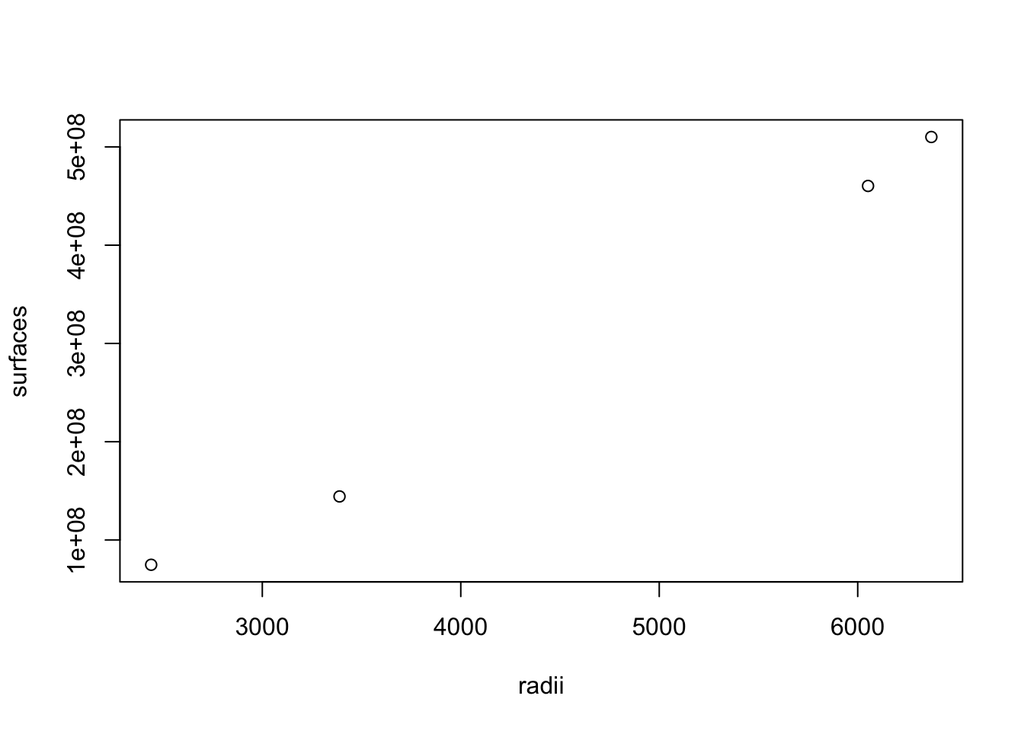

```r
plot(radii, surfaces)
```

**Aufgabe:** Wie viel Zeilen Code wäre in anderen Programmiersprache, die Du kennst, nötig, um Listen von Daten zu berechnen und in einem Diagramm zu visualieren?

### Die Funktion print()

Die Ausgabe von Variablen ist in einem Lehrbuch so wichtig, dass ich die Funktion `print()` gleich hier anspreche.

```r
print("Hallo!") # Direkte Ausgabe des Strings
```

```
## [1] "Hallo!"
```

```r
hallo <- "Hallo!"
print(hallo) # Ausgabe der Variablen hallo
```

```
## [1] "Hallo!"
```

Was bedeuten die Zeichen vor der Ausgabe?

Die beiden Rauten `##` vor der Ausgabe sind Kommentarzeichen. Sie bewirken, dass die Zeile nicht ausgeführt wird, wenn Du die Ausgabe mit “Copy and Paste” übernimmst. Bei einer gedruckten Ausgabe des Buches, geht das nicht. Sie dienen auch dazu, die Ausgabe als Ausgabe zu kennzeichnen.

Jetzt zähle ich von 1 bis 50

```r
print(1:50)
```

```
##  [1]  1  2  3  4  5  6  7  8  9 10 11 12 13 14 15 16 17 18 19 20 21 22 23
## [24] 24 25 26 27 28 29 30 31 32 33 34 35 36 37 38 39 40 41 42 43 44 45 46
## [47] 47 48 49 50
```

Du siehtst, dass die Zahl in eckigen Klammern dem Index der ersten Zahl in jeder Reihe entspricht.

**Aufgabe:** Fängt die Aufzählung mit null oder eins an?

Bei Zahlen von 1 bis 50 bringt Dir das keinen besonderen Nutzen. Schütteln wir die Zahlen also einmal ordentlich durch.

```r
print(sample(1:50))
```

```
##  [1] 49 26 35 24  2 13 23 39 27 31 25 20  4 29  7  6 15 42  1 33 38 47 41
## [24] 11 34 44 50 16 37 12  8 32 40 46  5 19 22 36 21 28 45 43 10 48  3 14
## [47] 17  9 30 18
```

**Aufgabe:** Welche Zahl hat den Index 30?

Meist wird die Funktion `print()` aber im Verborgenen ausgeführt. Werte werden automatisch ausgedruckt, wenn Du sie nicht in eine Variable schreibst oder anders weiter verwendst. Von diesem Feature mache ich in fast allen Beispielen dieses Buches gebrauch.

```r
hallo <- "hallo" # wird nicht ausgedruckt
"HALLO" # wird ausgedruckt
```

```
## [1] "HALLO"
```

Ausnahme: Werte werden nicht automatisch ausgedruckt, wenn sie in Schleifen stehen.

```r
for(counter in 1:2) {
    print("Hallo")
    "Welt"
}
```

```
## [1] "Hallo"
## [1] "Hallo"
```

**Aufgabe:** Gib die obigen Beispiele ohne `print()` aus, sobald Du R installierst hast.

- `"Hallo"`
- `hallo <- "Hallo!"; hallo`
- `1:50`
- `sample(1:50)`

### Was ist R?

> R is a free software environment for statistical computing and graphics. It compiles and runs on a wide variety of UNIX platforms, Windows and MacOS.

> https://www.r-project.org
- R ist eine Multiparadigmensprache:
  - dynamisch
  - funktional
  - eingeschränkt objektorientiert
- R ist eine freie Software Sammlung
  - für statisiche Berechnungen und ihre Visualisierung
  - mit Interpreter, Shell, IDE und Bibliotheken
  - die unter Unix, MacOs und Windows benutzt werden kann
- R ist in vielen Bereichen der Wissenschaft der de facto Standard zur Erstellung und Veröffentlichung von statistischen Forschungsergebnissen.
- R ist ein Werkzeug, das als Schnittstelle von grossen IT-Firmen in ihre Produkte implementiert wird.

### Was macht R besonders?

Zwei der besondere Stärken von R hast Du gerade kennen gerlernt. Erstens die unkomplizierte Weise, ganze Listen von Daten so einfach zu verarbeiten, als sei das ein einzelner Wert, zweitens die komfortablen Möglichkeiten, Daten als Diagramme zu visualisieren. R ist zudem auf allen verbreiteten Betriebssystemen einsetzbar, nämlich Linux, MacOS und Windows. Das ist vor allem im Vergleich mit Exel ein Vorteil, nicht zuletzt im Hinblick auf die Reproduzierbarkeit von Studien.

R versucht dem möglichst nahe zu kommen, wie der Wissenschaftler denkt. Einerseits sind das nicht unbedingt Schleifen, wie beim Programmierer. Andererseits sind das zum Beispiel die Zuweisungsoperatoren “<-”, wie sie in der wissenschaftlichen Schreibweise gebräuchlich sind.

Wie bei anderen Sprachen auch, ist vieles gewachsen und begründet sich dann als “historisch bedingt”. Zur Geschichte gibt es noch ein eigenes Kapitel.

Das Alleinstellungsmerkmal von R sind aber sicherlich die umfangreichen frei verfügbaren Bibliotheken, die dem Wissenschaftler zur Verfügung stehen, um Daten aufzuarbeiten, zu analysiern und zu visualisieren. Auch wie das getan wird, ist wissenschaftlich fundiert. Die Schritte folgen definierten Grammatiken.

Natürlich verabeiten alle Programmiersprachen Daten. Entscheidend ist also, wie die Daten betrachtet und genutzt werden. In der Wissenschaft steht der Erkenntnisgewinn im Vordergrund. Charakteristisch sind die Umformung der Daten, die Analyse und die Visualisierung.

Vergleicht man das mit Twitter, steht dort der Transport und die Vervielfältigung von Textnachrichten im Vordergrund, was zu anderen Anforderungen an die Software führt. Vergleicht man das mit einem Betriebssystem, steht dort die Anbindung der Hardware im Vordergrund, sowie die Aufteilung der Rechenzeit, was wiederum ganz andere Anforderungen an die Software stellt.

Im Regelfall lädt R die Daten komplett in den Arbeitsspeicher, bevor es mit der weiteren Verarbeitung beginnt. Das hat den Vorteil, dass Du sehr schnell und flexibel auch mit grossen Datenmengen jonglieren kannst, Stichwort Exploration. Für Twitter oder ein Betriebssystem wäre diese Herangehensweise gar nicht möglich, weil die Daten kontinuierlich strömen. Mit diesem Feature setzt sich R also zugleich auch eine wichtige Grenze. Für die Verabeitung von Datenstömen ist R nicht optimiert.

### Ist R eine Programmiersprache oder ein Werkzeug?

> R is a free software environment for statistical computing and graphics. It compiles and runs on a wide variety of UNIX platforms, Windows and MacOS.

> https://www.r-project.org

> R is more than a programming language. It is an interactive environment for doing statistics. I find it more helpful to think of R as having a programming language than being a programming language. The R language is the scripting language for the R environment, just as VBA is the scripting language for Microsoft Excel. Some of the more unusual features of the R language begin to make sense when viewed from this perspective."

> [John D. Cook](http://www.johndcook.com/blog/r_language_for_programmers/)

Die offizielle Definition lautet, R ist eine Entwicklungsumgebung für statistische Berechnungen und Graphiken. John D. Cook gibt die sehr diplomatische Definition, R sei eine Entwicklungsumgebung mit einer Skriptsprache und damit mehr als eine Programmiersprache.

Tatsächlich stellt sich die Frage, wie weit R auch eine allgemein einsetzbare Programmiersprache ist im Vergleich zu Java, C oder C++. Sicherlich ist es heute noch nicht so allgemein einsetzbar, wie weitreichend es aber einsetzbar ist, darauf fällt die Antwort sehr unterschiedlich aus, je nach Blickwinkel.

Oft lautet auch Frage auch, was im Bereich der Datenwissenschaft die bessere Sprache ist, Python oder R. R hat in diesem Bereich die umfangreichere Werkzeugsammlung, die Infrastruktur von Python ist breiter aufgestellt und kann damit besser Brücken schlagen. In der Bioinformatik bespielsweise, wo Algorithmen stärker im Vordergrung stehen als Datentabellen, Statistiken und Diagramme, gibt es eine höhere Affinität zu Python. Beide Sprachen sind so leicht zu lernen, dass nichts dagegen spricht sie gemeinsam einzusetzten. Schliesslich werden Konzepte zur Datenberechnung, die sich in R bewährt haben auch in Python übernommen, so dass die Grenzen zwischen beiden Sprachen abnehmen.

Die Sprache alleine ist auch nicht das alles Entscheidende. Genauso wichtig sind die verfügbaren Bibliotheken, Interpreter und Compiler, um das optimale Einsatzgebiet einer Sprache zu bestimmen. R wurde von Wissenschaftleren für Wissenschaftler entwickelt und gepflegt. Das hat das Profil der vorhandenen Werkzeuge geprägt. Datenanalyse wird aber auch in weiten Bereichen der Wirtschaft, der Politik oder des Journalismus immer wichtiger. Ensprechend weitet sich aus das Spektrum der Bibliotheken aus.

R ist heute u.a. geeignet, um datenzentierte Artikel und Bücher zu verfassen. Dieses Buch ist mithilfe solcher Bibliotheken erstellt. Es enstehen Bibliotheken, die die Veröffentlichung als Webseiten oder als mobile Apps unterstützen, mit zunehmenden interaktiven Möglichkeiten. IBM, Oracle, Microsoft, SAP, etc. implementieren Schnittstellen, um R als Werkzeug einbinden zu können.

Im Vergleich zu Java oder C++ ist R als universelle Programmiersprache heute noch weniger geeignet. Erstens ist sind seine objektorientieren Möglichkeiten noch nicht voll entwickelt, zweitens sind seine Bibliotheken sehr spezialisert und drittens setzt sein Speicherverhalten konzeptionlle Grenzen, die aber überwindbar sind.

R besetzte eine verwandte Lücke, für die Perl ursprünglich konzeptioniert war, als “Practical Extraction and Report Language”. Perl hat diese Nische unerwartet verlassen und wurde die erste Sprache der Internet Programmierung. In der Folge wurde es auf beiden Gebieten abgelöst, u.a wegen seiner Grenzen bei der Objektorientieren Programmierung und der zu langsamen Erneuerung der Sprache, aber vielleicht auch wegen des Verlustes seiner Spezialisierung. Wir finden Parallelen in R, sowohl bei den Chancen als auch bei den Risiken. Die Unterstützung durch Industrie und Wissenschaft ist aber viel umfassender als in der Geschichte von Perl.